# Named Entity Recognition

Tyler Spangler, Aaron Giddings, Max Thompson

18 November 2019

There are multiple different R packages that can perfrom Named Entity Recognition (NER). A few include trinker/entity, monkeylearn, openNLP, and spaCyR. trinker/entity package is from github and when experimenting with this package, it would output items that were not named entities. Additionally, to extract the entities, you must specify in the command which entity you are extracting. The monkeylearn package interfaces with the MonkeyLearn API which is a machine learning platform on the cloud. We downloaded the API key from the website, but quickly ran out of runs against the API. The openNLP package interfaces to the Apache OpenNlp which is a machine learning based toolkit for NLP text written in java. The spaCyR package is an R wrapper to the Python spaCy NLP package. We tried both openNLP and spaCyR and found that spaCyR was easier to extract the entities and other aspects of the text. The openNLP package worked, but the output was not as easily readable or intereptable as the spaCyR output. A downside to spaCyR is that it requires a Python environment to operate and can take a while to load the first time. Instructions for loading spaCyR can be found at https://spacyr.quanteda.io/. This “tutorial” will use spaCyR.

The first step is to load the required packages and load the data using Huf’s code. The command spacy_initialize() is an important command that loads the miniconda environment that spaCyR will use to run the functions. We do not unnest the tokens when loading the data and leave the comments intact.

```r
pacman::p_load(tidyr,
               tidytext,
               tidyverse,
               textdata,
               dplyr,
               stringr,
               ggplot2,
               magrittr,
               wordcloud,
               reshape2,
               entity,
               monkeylearn,
               quanteda,
               spacyr,
               rJava,
               NLP,
               openNLP)

spacy_initialize()
```

```
## Found 'spacy_condaenv'. spacyr will use this environment
```

```
## successfully initialized (spaCy Version: 2.2.2, language model: en)
```

```
## (python options: type = "condaenv", value = "spacy_condaenv")
```

```r
root <- rprojroot::find_root(rprojroot::is_rstudio_project)
file_loc <- file.path(root,"data","phone_user_reviews")

file_list <- list.files(path = file_loc,
                        pattern = "",
                        full.names = TRUE)
reviews_tidy <- tibble::tibble()
manu_pattern <- "/cellphones/[a-z0-9]+"
prod_pattern <- paste(manu_pattern, "-|/", sep = "")
for (i in file_list){
  input <- load(i,ex <- new.env())
  text_raw <- get(ls(ex),ex)
  text_en <- text_raw[text_raw$lang=="en",]
  rm(ex, text_raw, input, i)

  clean <- tibble::tibble(score = text_en$score,
                          maxscore = text_en$score_max,
                          text = text_en$extract,
                          product = gsub(prod_pattern, "", text_en$phone_url),
                          author = text_en$author,
                          manufacturer = gsub("/cellphones/","",str_extract(text_en$phone_url,manu_pattern)))#%>%
  #tidytext::unnest_tokens(word, text)
  reviews_tidy <- base::rbind(reviews_tidy, clean)
  rm(text_en, clean)
}
rm(file_list, root, manu_pattern, prod_pattern, file_loc)
```

With the data loaded in the tibble, reviews_tidy, spaCyR can be used to parse out the data. Before using the spacy_parse command, the data must be in a data.frame and only the comment column is run through the command. This command will unnest the tokens and perform part of speech tagging, lemmatizing, and NER on the token. With this command performing so many functions, it takes a long time to run on the more than 550,000 rows of the original data. For the purpose of this tutorial, we will run the spacy_parse function on a set of 100 rows from the original data.

```r
presentation_data <- as.data.frame(reviews_tidy[1:100,], stringsAsFactors = FALSE)
presentation_parsed <- spacy_parse(presentation_data$text, entity = TRUE)
head(presentation_parsed)
```

```
##   doc_id sentence_id token_id   token   lemma   pos entity
## 1  text1           1        1      As      as SCONJ
## 2  text1           1        2       a       a   DET
## 3  text1           1        3 diehard diehard   ADJ
## 4  text1           1        4 Samsung Samsung PROPN  ORG_B
## 5  text1           1        5     fan     fan  NOUN
## 6  text1           1        6     who     who  PRON
```

```r
presentation_extracted <- entity_extract(presentation_parsed)
head(presentation_extracted)
```

```
##   doc_id sentence_id  entity entity_type
## 1  text1           1 Samsung         ORG
## 2  text1           1 Samsung         ORG
## 3  text1           1       S         LAW
## 4  text3           4 Samsung         ORG
## 5  text4           3 Samsung         ORG
## 6  text4           3      S4     PRODUCT
```

To load the full data, the data was split into increments of 50,000 rows and parsed. The parsed increments were each saved as a .Rdata file. After each subset was parsed, it was combined into one dataset and the entities were extracted using the entity_extract function (demonstrated above) and saved as a .RData file in the NER folder in my student folder. The remaining portion of this "tutorial will use the compiled data set.

```r
setwd("C:/Users/Tyler/Documents/oper655_fa2019/student_project_folders/oper655_fa2019_spangler/NER")
load("fullextracted.RData")
head(full_extracted)
```

```
##   doc_id sentence_id  entity entity_type
## 1  text1           1 Samsung         ORG
## 2  text1           1 Samsung         ORG
## 3  text1           1       S         LAW
## 4  text3           4 Samsung         ORG
## 5  text4           2     One    CARDINAL
## 6  text4           3 Samsung         ORG
```

With the full data loaded, we can look at the counts for different entities and what the most common named entities are.

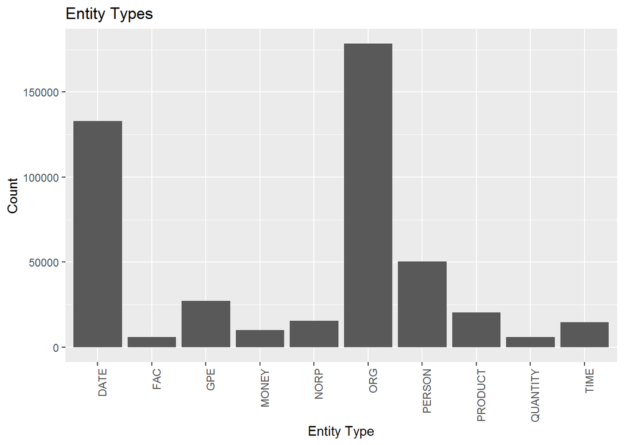

```r
full_extracted %>%
  filter(entity_type != "CARDINAL" & entity_type != "ORDINAL") %>%
  count(entity_type) %>%
  top_n(10) %>%
  ggplot(aes(x = entity_type, y = n)) +
  geom_bar(stat = "identity") +
  theme(axis.text.x = element_text(angle = 90, hjust = 1)) +
  labs(title = "Entity Types") +
  xlab("Entity Type") +
  ylab("Count")
```

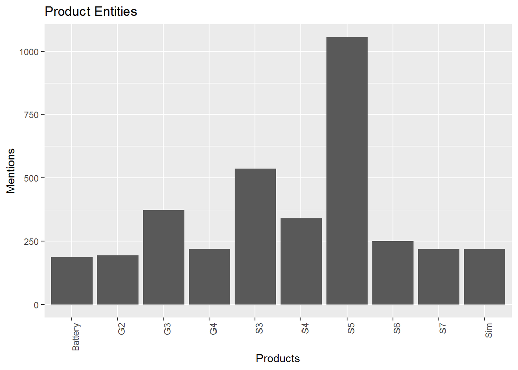

```r
full_extracted %>%
  filter(entity_type == "PRODUCT") %>%
  group_by(entity_type) %>%
  count(entity) %>%
  top_n(10) %>%
  ggplot(aes(x = entity, y = n)) +
  geom_bar(stat = "identity") +
  theme(axis.text.x = element_text(angle = 90, hjust = 1)) +
  labs(title = "Product Entities") +
  xlab("Products") +
  ylab("Mentions")
```

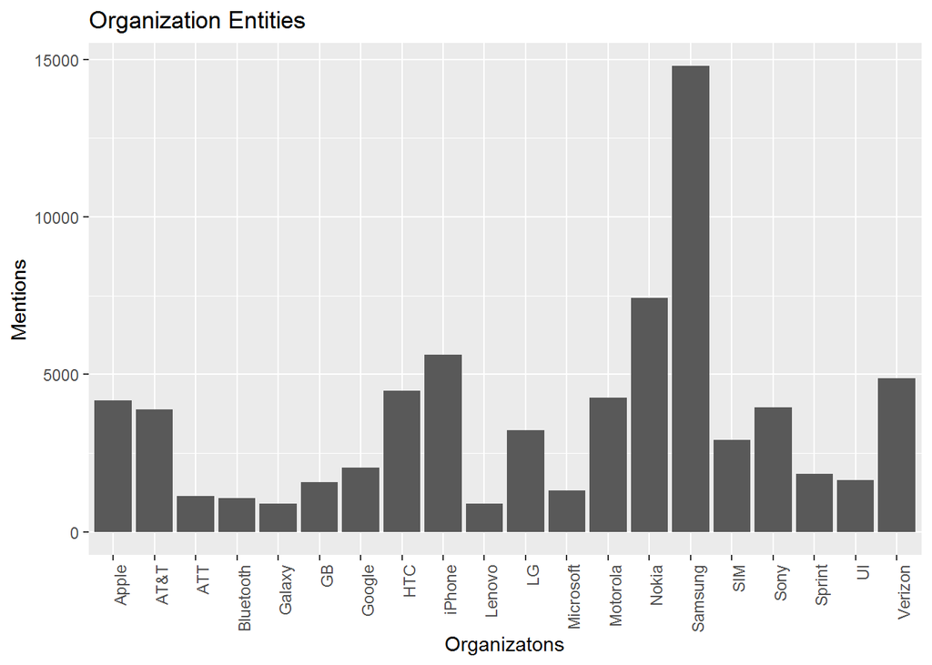

```r
full_extracted %>%
  filter(entity_type == "ORG") %>%
  group_by(entity_type) %>%
  count(entity) %>%
  top_n(20) %>%
  ggplot(aes(x = entity, y = n)) +
  geom_bar(stat = "identity") +
  theme(axis.text.x = element_text(angle = 90, hjust = 1)) +
  labs(title = "Organization Entities") +
  xlab("Organizatons") +
  ylab("Mentions")
```

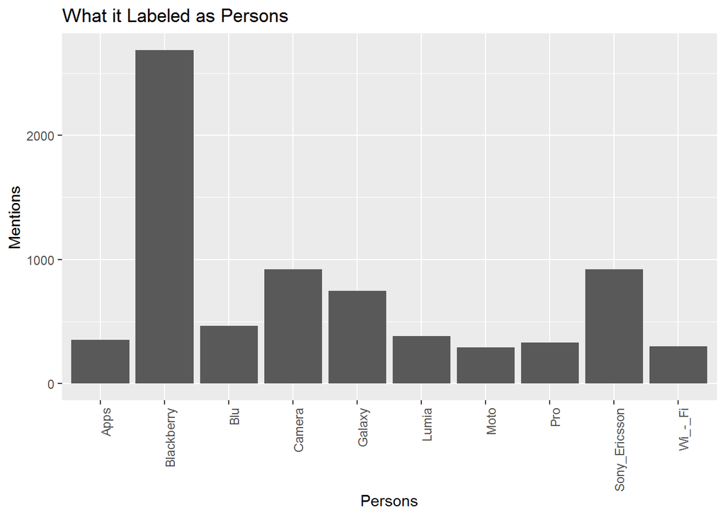

```r
full_extracted %>%
  filter(entity_type == "PERSON" ) %>%
  group_by(entity_type) %>%
  count(entity) %>%
  top_n(10) %>%
  ggplot(aes(x = entity, y = n)) +
  geom_bar(stat = "identity") +
  theme(axis.text.x = element_text(angle = 90, hjust = 1)) +
  labs(title = "What it Labeled as Persons") +
  xlab("Persons") +
  ylab("Mentions")
```

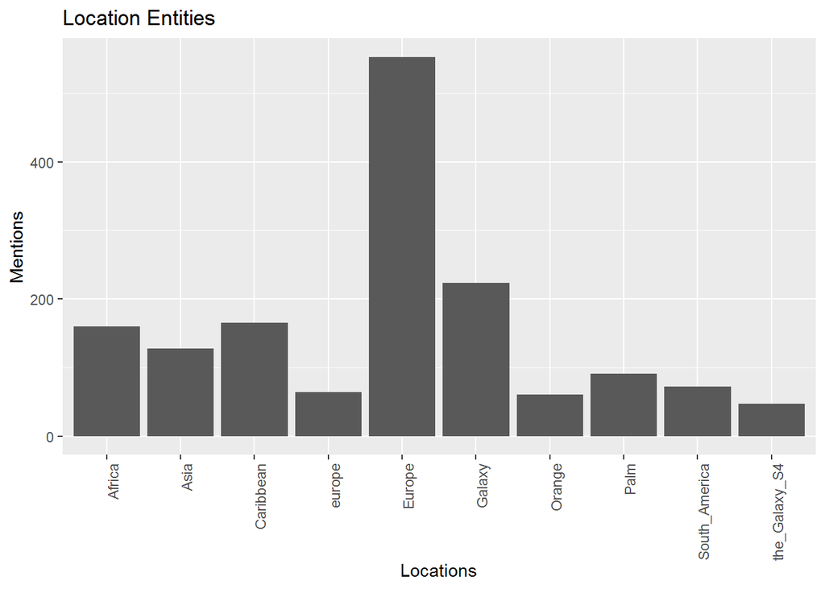

```r
full_extracted %>%
  filter(entity_type == "LOC" ) %>%
  group_by(entity_type) %>%
  count(entity) %>%
  top_n(10) %>%
  ggplot(aes(x = entity, y = n)) +
  geom_bar(stat = "identity") +
  theme(axis.text.x = element_text(angle = 90, hjust = 1)) +
labs(title = "Location Entities") +
  xlab("Locations") +
  ylab("Mentions")
```

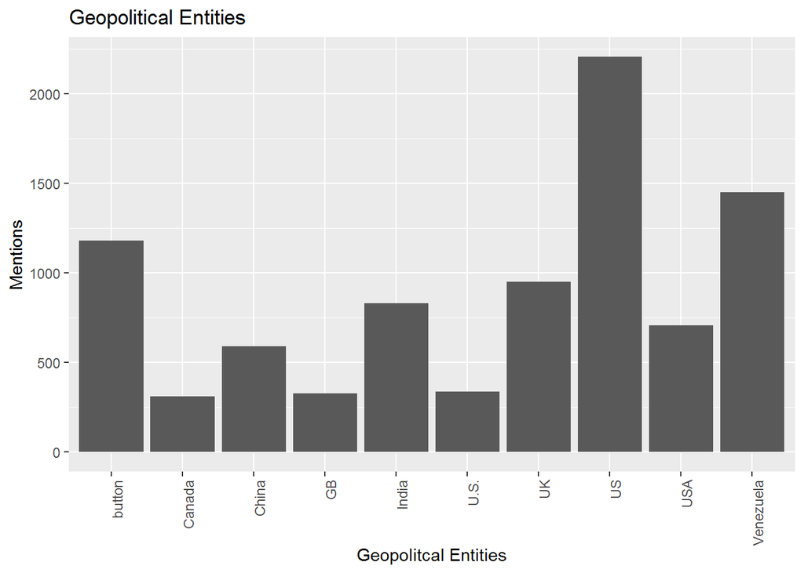

```r
full_extracted %>%
  filter(entity_type == "GPE" ) %>%
  group_by(entity_type) %>%
  count(entity) %>%
  top_n(10) %>%
  ggplot(aes(x = entity, y = n)) +
  geom_bar(stat = "identity") +
  theme(axis.text.x = element_text(angle = 90, hjust = 1))+
  labs(title = "Geopolitical Entities") +
  xlab("Geopolitcal Entities") +
  ylab("Mentions")
```

As mentioned in the general NER presentation, there are a few different uses of NER. The first application is to use NER as a search algorithm. In our dataset, the manufacturer is already listed as a column, so this is not really necessary, but not using the manufacturer column or imagining that it is gone, we can use NER to extract only the reviews that mention certain manufacturers. The reviews may not be about their phones in particular, but they may also contain comparisons between two companies. Samsung is the most commonly occuring organization so we will start with Samsung.

```r
samsung_reviews <- full_extracted %>%
  filter(entity == "Samsung" | entity == "samsung") %>%
  mutate(rownum = str_sub(doc_id, 5))

all_samsung_reviews <- reviews_tidy[c(samsung_reviews$rownum),]
head(all_samsung_reviews)
```

```
## # A tibble: 6 x 6
##   score maxscore text                         product  author  manufacturer
##   <dbl>    <dbl> <chr>                        <chr>    <chr>   <chr>
## 1  10         10 As a diehard Samsung fan wh~ galaxy-~ CarolA~ samsung
## 2  10         10 As a diehard Samsung fan wh~ galaxy-~ CarolA~ samsung
## 3   6         10 Adequate feel. Nice heft. P~ galaxy-~ R. Cra~ samsung
## 4   9.2       10 Never disappointed. One of ~ galaxy-~ Buster~ samsung
## 5  10         10 I am the type of person who~ galaxy-~ BDB76   samsung
## 6   6         10 It is an extremely advanced~ galaxy-~ Mr Alan samsung
```

The same can be done with Nokia which is the second most common organization entity.

```r
nokia_reviews <- full_extracted %>%
  filter(entity == "Nokia" | entity == "nokia") %>%
  mutate(rownum = str_sub(doc_id, 5))

all_nokia_reviews <- reviews_tidy[c(nokia_reviews$rownum),]
head(all_nokia_reviews)
```

```
## # A tibble: 6 x 6
##   score maxscore text                       product   author   manufacturer
##   <dbl>    <dbl> <chr>                      <chr>     <chr>    <chr>
## 1   9.6       10 I have been an iOS user f~ galaxy-s~ gone2ut~ samsung
## 2  10         10 There are so many critiqu~ galaxy-s~ cri8ive~ samsung
## 3  10         10 Best phone I've ever had.~ galaxy-s~ Carlos ~ samsung
## 4   8         10 I'm really liking this ph~ galaxy-s~ Dr. Sna~ samsung
## 5   8         10 I switched to Samsung aft~ galaxy-s~ Magnus ~ samsung
## 6   4         10 Apple iPhone has changed ~ iphone-6~ R.G.     apple
```

Finally, we can do the same for Apple to see the reviews for Apple.

```r
apple_reviews <- full_extracted %>%
  filter(entity == "Apple" | entity == "apple") %>%
  mutate(rownum = str_sub(doc_id, 5))

all_apple_reviews<- reviews_tidy[c(apple_reviews$rownum),]
head(all_apple_reviews)
```

```
## # A tibble: 6 x 6
##   score maxscore text                       product  author    manufacturer
##   <dbl>    <dbl> <chr>                      <chr>    <chr>     <chr>
## 1    10       10 Took the risk and bought ~ galaxy-~ Dwakal    samsung
## 2    10       10 The S8 is a more elegant ~ galaxy-~ SquareBH  samsung
## 3    10       10 The S8 is a more elegant ~ galaxy-~ SquareBH  samsung
## 4    10       10 This phone is great. If y~ galaxy-~ Charleye~ samsung
## 5    10       10 No phone on earth comes c~ galaxy-~ boinero   samsung
## 6    10       10 Best phone I have used ev~ galaxy-~ D. F.     samsung
```

This same concept can be applied to different kinds of phones. S5 was the most commonly mentioned product entity.

```r
s5_reviews <- full_extracted %>%
  filter(entity == "S5" | entity == "s5") %>%
  mutate(rownum = str_sub(doc_id, 5))

all_s5_reviews <- reviews_tidy[c(s5_reviews$rownum),]
head(all_s5_reviews)
```

```
## # A tibble: 6 x 6
##   score maxscore text                          product  author manufacturer
##   <dbl>    <dbl> <chr>                         <chr>    <chr>  <chr>
## 1     4       10 Had the Galaxy S5 and though~ galaxy-~ billd~ samsung
## 2     4       10 Had the Galaxy S5 and though~ galaxy-~ billd~ samsung
## 3    10       10 "went from S5 to LG G5 thoug~ galaxy-~ Carl   samsung
## 4    10       10 I went from the S5 to this. ~ galaxy-~ Cyndi~ samsung
## 5    10       10 Did the upgrade from s5 to s~ galaxy-~ Ritzzk samsung
## 6    10       10 No Regrets. Superb Quality F~ galaxy-~ Dusty  samsung
```

Another application of NER is being able to use sentitment analysis on named entities. After doing a search and extracting only reviews that mention an organization or product, we can use sentiment analysis on these reviews to get an idea of how people are viewing different organizations or products.

```r
all_samsung_reviews %>%
  unnest_tokens(word, text) %>%
  inner_join(get_sentiments("bing")) %>%
  count(index = author, sentiment) %>%
  spread(sentiment, n, fill = 0) %>%
  mutate(sentiment = positive - negative) %>%
  arrange(desc(sentiment)) %>%
  top_n(10)
```

```
## # A tibble: 12 x 4
##    index           negative positive sentiment
##    <chr>              <dbl>    <dbl>     <dbl>
##  1 Amazon Customer      751     2531      1780
##  2 Anonymous            147     1029       882
##  3 Michael                2       48        46
##  4 WDBJr                  4       40        36
##  5 Matgee04               0       32        32
##  6 happyuser5000          0       30        30
##  7 Slimjim76              0       28        28
##  8 surrey parent          0       28        28
##  9 <NA>                   2       30        28
## 10 David                 12       39        27
## 11 Drjeppe                0       27        27
## 12 Elena Selena           0       27        27
```

```r
#Can also arrange to see the most negative reviews
all_samsung_reviews %>%
  unnest_tokens(word, text) %>%
  inner_join(get_sentiments("bing")) %>%
  count(index = author, sentiment) %>%
  spread(sentiment, n, fill = 0) %>%
  mutate(sentiment = positive - negative) %>%
  arrange(sentiment) %>%
  top_n(10)
```

```
## # A tibble: 12 x 4
##    index           negative positive sentiment
##    <chr>              <dbl>    <dbl>     <dbl>
##  1 David                 12       39        27
##  2 Drjeppe                0       27        27
##  3 Elena Selena           0       27        27
##  4 Slimjim76              0       28        28
##  5 surrey parent          0       28        28
##  6 <NA>                   2       30        28
##  7 happyuser5000          0       30        30
##  8 Matgee04               0       32        32
##  9 WDBJr                  4       40        36
## 10 Michael                2       48        46
## 11 Anonymous            147     1029       882
## 12 Amazon Customer      751     2531      1780
```

This can be applied to both Nokia and Apple to determine the sentiment associated with the reviews that mention these two companies.

```r
all_apple_reviews %>%
  unnest_tokens(word, text) %>%
  inner_join(get_sentiments("bing")) %>%
  count(index = author, sentiment) %>%
  spread(sentiment, n, fill = 0) %>%
  mutate(sentiment = positive - negative) %>%
  arrange(desc(sentiment)) %>%
  top_n(10)
```

```
## # A tibble: 11 x 4
##    index             negative positive sentiment
##    <chr>                <dbl>    <dbl>     <dbl>
##  1 Amazon Customer        362     1044       682
##  2 Anonymous               42      190       148
##  3 Jagat Joshi              0       48        48
##  4 Jack Black               4       36        32
##  5 Maryiscute10             3       24        21
##  6 Asir                     0       20        20
##  7 LuvIsa4LetterWord        0       20        20
##  8 Usha Sankar              0       20        20
##  9 AQualityBuyer            0       18        18
## 10 Grahame_E                0       18        18
## 11 TTPP                     0       18        18
```

```r
all_nokia_reviews %>%
  unnest_tokens(word, text) %>%
  inner_join(get_sentiments("bing")) %>%
  count(index = author, sentiment) %>%
  spread(sentiment, n, fill = 0) %>%
  mutate(sentiment = positive - negative) %>%
  arrange(desc(sentiment)) %>%
  top_n(10)
```

```
## # A tibble: 12 x 4
##    index           negative positive sentiment
##    <chr>              <dbl>    <dbl>     <dbl>
##  1 Amazon Customer      571     1854      1283
##  2 Anonymous             69      421       352
##  3 Johnny Amazon®         0       36        36
##  4 Cynamonne              0       27        27
##  5 Alex                   0       22        22
##  6 Andrew                 5       27        22
##  7 Jshep311               0       21        21
##  8 Vaishnav               0       21        21
##  9 <NA>                   4       25        21
## 10 farees                 0       20        20
## 11 NaninIndy              2       22        20
## 12 Tim                    0       20        20
```

Being able to apply sentiment to the three companies allows us to compare the total sentiment for each company. The sentiment values for each phone are summed and divided by the total number of reviews that mention each brand.

```r
all_nokia_reviews %>%
  unnest_tokens(word, text) %>%
  inner_join(get_sentiments("bing")) %>%
  count(index = author, sentiment) %>%
  spread(sentiment, n, fill = 0) %>%
  mutate(sentiment = positive - negative) %>%
  summarise(sum(sentiment)/7575)
```

```
## # A tibble: 1 x 1
##   `sum(sentiment)/7575`
##                   <dbl>
## 1                  2.01
```

```r
all_samsung_reviews %>%
  unnest_tokens(word, text) %>%
  inner_join(get_sentiments("bing")) %>%
  count(index = author, sentiment) %>%
  spread(sentiment, n, fill = 0) %>%
  mutate(sentiment = positive - negative) %>%
  summarise(sum(sentiment)/14937)
```

```
## # A tibble: 1 x 1
##   `sum(sentiment)/14937`
##                    <dbl>
## 1                   2.17
```

```r
all_apple_reviews %>%
  unnest_tokens(word, text) %>%
  inner_join(get_sentiments("bing")) %>%
  count(index = author, sentiment) %>%
  spread(sentiment, n, fill = 0) %>%
  mutate(sentiment = positive - negative) %>%
  summarise(sum(sentiment)/4400)
```

```
## # A tibble: 1 x 1
##   `sum(sentiment)/4400`
##                   <dbl>
## 1                  1.79
```